# Supervised Learning - ReCell Project

## Problem Statement

### Business Context

Buying and selling used phones and tablets used to be something that happened on a handful of online marketplace sites. But the used and refurbished device market has grown considerably over the past decade, and a new IDC (International Data Corporation) forecast predicts that the used phone market would be worth \$52.7bn by 2023 with a compound annual growth rate (CAGR) of 13.6% from 2018 to 2023. This growth can be attributed to an uptick in demand for used phones and tablets that offer considerable savings compared with new models.

Refurbished and used devices continue to provide cost-effective alternatives to both consumers and businesses that are looking to save money when purchasing one. There are plenty of other benefits associated with the used device market. Used and refurbished devices can be sold with warranties and can also be insured with proof of purchase. Third-party vendors/platforms, such as Verizon, Amazon, etc., provide attractive offers to customers for refurbished devices. Maximizing the longevity of devices through second-hand trade also reduces their environmental impact and helps in recycling and reducing waste. The impact of the COVID-19 outbreak may further boost this segment as consumers cut back on discretionary spending and buy phones and tablets only for immediate needs.

### Objective

The rising potential of this comparatively under-the-radar market fuels the need for an ML-based solution to develop a dynamic pricing strategy for used and refurbished devices. ReCell, a startup aiming to tap the potential in this market, has hired you as a data scientist. They want you to analyze the data provided and build a linear regression model to predict the price of a used phone/tablet and identify factors that significantly influence it.

### Data Description

The data contains the different attributes of used/refurbished phones and tablets. The data was collected in the year 2021. The detailed data dictionary is given below.

- brand_name: Name of manufacturing brand
- os: OS on which the device runs
- screen_size: Size of the screen in cm
- 4g: Whether 4G is available or not
- 5g: Whether 5G is available or not
- main_camera_mp: Resolution of the rear camera in megapixels
- selfie_camera_mp: Resolution of the front camera in megapixels
- int_memory: Amount of internal memory (ROM) in GB
- ram: Amount of RAM in GB
- battery: Energy capacity of the device battery in mAh
- weight: Weight of the device in grams
- release_year: Year when the device model was released
- days_used: Number of days the used/refurbished device has been used
- normalized_new_price: Normalized price of a new device of the same model in euros
- normalized_used_price: Normalized price of the used/refurbished device in euros

## Importing necessary libraries

```python
# this will help in making the Python code more structured automatically (good coding practice)
%load_ext nb_black

# Libraries to help with reading and manipulating data
import numpy as np
import pandas as pd

# Libraries to help with data visualization
import matplotlib.pyplot as plt
import seaborn as sns

sns.set()

# split the data into train and test
from sklearn.model_selection import train_test_split

# to build linear regression_model
import statsmodels.api as sm

# to check model performance
from sklearn.metrics import mean_absolute_error, mean_squared_error, r2_score
```

## Loading the dataset

```python
data = pd.read_csv("used_device_data.csv")
```

## Data Overview

- Observations
- Sanity checks

```python
data.head()
```

|  | brand_name | os | screen_size | 4g | 5g | main_camera_mp | selfie_camera_mp | int_memory | ram | battery | weight | release_year | days_used | normalized_used_price | normalized_new_price |
| --- | --- | --- | --- | --- | --- | --- | --- | --- | --- | --- | --- | --- | --- | --- | --- |
| 0 | Honor | Android | 14.50 | yes | no | 13.0 | 5.0 | 64.0 | 3.0 | 3020.0 | 146.0 | 2020 | 127 | 4.307572 | 4.715100 |
| 1 | Honor | Android | 17.30 | yes | yes | 13.0 | 16.0 | 128.0 | 8.0 | 4300.0 | 213.0 | 2020 | 325 | 5.162097 | 5.519018 |
| 2 | Honor | Android | 16.69 | yes | yes | 13.0 | 8.0 | 128.0 | 8.0 | 4200.0 | 213.0 | 2020 | 162 | 5.111084 | 5.884631 |
| 3 | Honor | Android | 25.50 | yes | yes | 13.0 | 8.0 | 64.0 | 6.0 | 7250.0 | 480.0 | 2020 | 345 | 5.135387 | 5.630961 |
| 4 | Honor | Android | 15.32 | yes | no | 13.0 | 8.0 | 64.0 | 3.0 | 5000.0 | 185.0 | 2020 | 293 | 4.389995 | 4.947837 |

```python
data.shape
```

```
(3454, 15)
```

There are 3454 rows and 15 columns in the data.

```python
data.info()
```

```
<class 'pandas.core.frame.DataFrame'>
RangeIndex: 3454 entries, 0 to 3453
Data columns (total 15 columns):
 #   Column                 Non-Null Count  Dtype
---  ------                 --------------  -----
 0   brand_name             3454 non-null   object
 1   os                     3454 non-null   object
 2   screen_size            3454 non-null   float64
 3   4g                     3454 non-null   object
 4   5g                     3454 non-null   object
 5   main_camera_mp         3275 non-null   float64
 6   selfie_camera_mp       3452 non-null   float64
 7   int_memory             3450 non-null   float64
 8   ram                    3450 non-null   float64
 9   battery                3448 non-null   float64
 10  weight                 3447 non-null   float64
 11  release_year           3454 non-null   int64
 12  days_used              3454 non-null   int64
 13  normalized_used_price  3454 non-null   float64
 14  normalized_new_price   3454 non-null   float64
dtypes: float64(9), int64(2), object(4)
memory usage: 404.9+ KB
```

There are 11 numeric and 4 categorical columns in the data.

```python
data.describe(include="all").T
```

|  | count | unique | top | freq | mean | std | min | 25% | 50% | 75% | max |
| --- | --- | --- | --- | --- | --- | --- | --- | --- | --- | --- | --- |
| brand_name | 3454 | 34 | Others | 502 | NaN | NaN | NaN | NaN | NaN | NaN | NaN |
| os | 3454 | 4 | Android | 3214 | NaN | NaN | NaN | NaN | NaN | NaN | NaN |
| screen_size | 3454.0 | NaN | NaN | NaN | 13.713115 | 3.80528 | 5.08 | 12.7 | 12.83 | 15.34 | 30.71 |
| 4g | 3454 | 2 | yes | 2335 | NaN | NaN | NaN | NaN | NaN | NaN | NaN |
| 5g | 3454 | 2 | no | 3302 | NaN | NaN | NaN | NaN | NaN | NaN | NaN |
| main_camera_mp | 3275.0 | NaN | NaN | NaN | 9.460208 | 4.815461 | 0.08 | 5.0 | 8.0 | 13.0 | 48.0 |
| selfie_camera_mp | 3452.0 | NaN | NaN | NaN | 6.554229 | 6.970372 | 0.0 | 2.0 | 5.0 | 8.0 | 32.0 |
| int_memory | 3450.0 | NaN | NaN | NaN | 54.573099 | 84.972371 | 0.01 | 16.0 | 32.0 | 64.0 | 1024.0 |
| ram | 3450.0 | NaN | NaN | NaN | 4.036122 | 1.365105 | 0.02 | 4.0 | 4.0 | 4.0 | 12.0 |
| battery | 3448.0 | NaN | NaN | NaN | 3133.402697 | 1299.682844 | 500.0 | 2100.0 | 3000.0 | 4000.0 | 9720.0 |
| weight | 3447.0 | NaN | NaN | NaN | 182.751871 | 88.413228 | 69.0 | 142.0 | 160.0 | 185.0 | 855.0 |
| release_year | 3454.0 | NaN | NaN | NaN | 2015.965258 | 2.298455 | 2013.0 | 2014.0 | 2015.5 | 2018.0 | 2020.0 |
| days_used | 3454.0 | NaN | NaN | NaN | 674.869716 | 248.580166 | 91.0 | 533.5 | 690.5 | 868.75 | 1094.0 |
| normalized_used_price | 3454.0 | NaN | NaN | NaN | 4.364712 | 0.588914 | 1.536867 | 4.033931 | 4.405133 | 4.7557 | 6.619433 |
| normalized_new_price | 3454.0 | NaN | NaN | NaN | 5.233107 | 0.683637 | 2.901422 | 4.790342 | 5.245892 | 5.673718 | 7.847841 |

The most common operating system is Android.

The average battery size is 3133 mAh.

The average weight is 182.75 grams.

##### Checking for duplicate values

```python
data.duplicated().sum()
```

```
0
```

There are no duplicate values in the data.

##### Checking for missing values

```python
data.isnull().sum()
```

```
brand_name                 0
os                         0
screen_size                0
4g                         0
5g                         0
main_camera_mp           179
selfie_camera_mp           2
int_memory                 4
ram                        4
battery                    6
weight                     7
release_year               0
days_used                  0
normalized_used_price      0
normalized_new_price       0
dtype: int64
```

Main_camera_mp, selfie_camera_mp, int_memory, ram, battery, and weight all have missing values.

```python
# create a copy of the data so that original data does not get changed
df = data.copy()
```

## Exploratory Data Analysis (EDA)

```python
# Define a function in order to create a combined histogram and barplot


def histogram_boxplot(data, feature, figsize=(15, 10), kde=False, bins=None):
    """
    Boxplot and histogram combined

    data: dataframe
    feature: dataframe column
    figsize: size of figure (default (15,10))
    kde: whether to show the density curve (default False)
    bins: number of bins for histogram (default None)
    """
    f2, (ax_box2, ax_hist2) = plt.subplots(
        nrows=2,  # Number of rows of the subplot grid= 2
        sharex=True,  # x-axis will be shared among all subplots
        gridspec_kw={"height_ratios": (0.25, 0.75)},
        figsize=figsize,
    )  # creating the 2 subplots
    sns.boxplot(
        data=data, x=feature, ax=ax_box2, showmeans=True, color="violet"
    )  # boxplot will be created and a triangle will indicate the mean value of the column
    sns.histplot(
        data=data, x=feature, kde=kde, ax=ax_hist2, bins=bins
    ) if bins else sns.histplot(
        data=data, x=feature, kde=kde, ax=ax_hist2
    )  # For histogram
    ax_hist2.axvline(
        data[feature].mean(), color="green", linestyle="--"
    )  # Add mean to the histogram
    ax_hist2.axvline(
        data[feature].median(), color="black", linestyle="-"
    )  # Add median to the histogram
```

```python
# Define a function in order to create a labeled boxplot and histogram combined


def histogram_boxplot(data, feature, figsize=(15, 10), kde=False, bins=None):
    """
    Boxplot and histogram combined

    data: dataframe
    feature: dataframe column
    figsize: size of figure (default (15,10))
    kde: whether to show the density curve (default False)
    bins: number of bins for histogram (default None)
    """
    f2, (ax_box2, ax_hist2) = plt.subplots(
        nrows=2,  # Number of rows of the subplot grid= 2
        sharex=True,  # x-axis will be shared among all subplots
        gridspec_kw={"height_ratios": (0.25, 0.75)},
        figsize=figsize,
    )  # creating the 2 subplots
    sns.boxplot(
        data=data, x=feature, ax=ax_box2, showmeans=True, color="violet"
    )  # boxplot will be created and a triangle will indicate the mean value of the column
    sns.histplot(
        data=data, x=feature, kde=kde, ax=ax_hist2, bins=bins
    ) if bins else sns.histplot(
        data=data, x=feature, kde=kde, ax=ax_hist2
    )  # For histogram
    ax_hist2.axvline(
        data[feature].mean(), color="green", linestyle="--"
    )  # Add mean to the histogram
    ax_hist2.axvline(
        data[feature].median(), color="black", linestyle="-"
    )  # Add median to the histogram
```

```python
# function to create labeled barplots


def labeled_barplot(data, feature, perc=False, n=None):
    """
    Barplot with percentage at the top

    data: dataframe
    feature: dataframe column
    perc: whether to display percentages instead of count (default is False)
    n: displays the top n category levels (default is None, i.e., display all levels)
    """

    total = len(data[feature])  # length of the column
    count = data[feature].nunique()
    if n is None:
        plt.figure(figsize=(count + 2, 6))
    else:
        plt.figure(figsize=(n + 2, 6))

    plt.xticks(rotation=90, fontsize=15)
    ax = sns.countplot(
        data=data,
        x=feature,
        palette="Paired",
        order=data[feature].value_counts().index[:n],
    )

    for p in ax.patches:
        if perc == True:
            label = "{:.1f}%".format(
                100 * p.get_height() / total
            )  # percentage of each class of the category
        else:
            label = p.get_height()  # count of each level of the category

        x = p.get_x() + p.get_width() / 2  # width of the plot
        y = p.get_height()  # height of the plot

        ax.annotate(
            label,
            (x, y),
            ha="center",
            va="center",
            size=12,
            xytext=(0, 5),
            textcoords="offset points",
        )  # annotate the percentage

    plt.show()  # show the plot
```

## Univariate Analysis

#### Brand Name

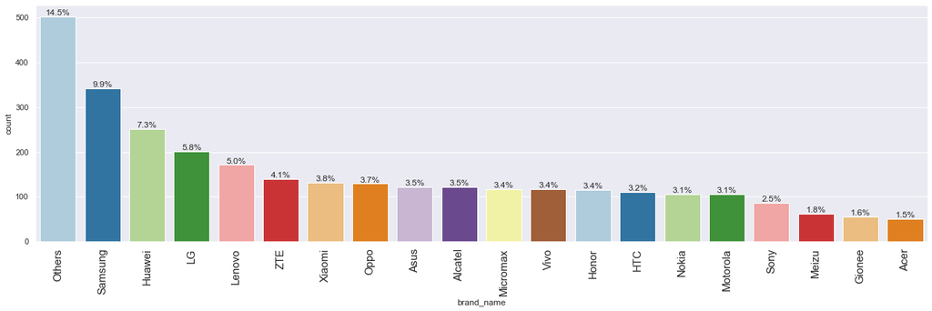

```python
labeled_barplot(df, "brand_name", perc=True, n=20)
```

```python
df["brand_name"].value_counts()
```

```
Others        502
Samsung       341
Huawei        251
LG            201
Lenovo        171
ZTE           140
Xiaomi        132
Oppo          129
Asus          122
Alcatel       121
Micromax      117
Vivo          117
Honor         116
HTC           110
Nokia         106
Motorola      106
Sony           86
Meizu          62
Gionee         56
Acer           51
XOLO           49
Panasonic      47
Realme         41
Apple          39
Lava           36
Celkon         33
Spice          30
Karbonn        29
Coolpad        22
BlackBerry     22
Microsoft      22
OnePlus        22
Google         15
Infinix        10
Name: brand_name, dtype: int64
```

The most common brand name is listed as 'others', followed by Samsung, Huawei, and LG.

#### Operating System (os)

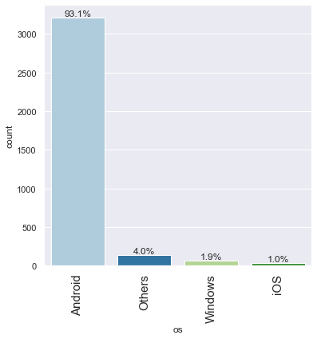

```python
labeled_barplot(df, "os", perc=True)
```

```python
df["os"].value_counts()
```

```
Android    3214
Others      137
Windows      67
iOS          36
Name: os, dtype: int64
```

The majority of all phones are using the Android operating system. (93.1% or 3214 phones).

#### Screen Size in cm

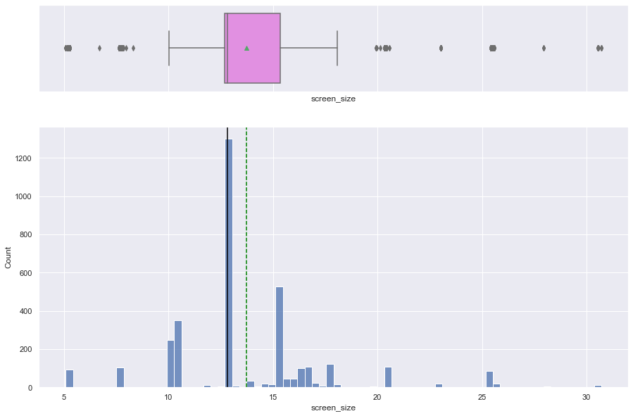

```python
histogram_boxplot(df, "screen_size")
```

```python
df["screen_size"].median()
```

```
12.83
```

```python
df["screen_size"].min()
```

```
5.08
```

```python
df["screen_size"].max()
```

```
30.71
```

The median screen size is 12.83cm. The largest screen size is 30.71cm and the smallest is 5.08cm.

#### 4G availability

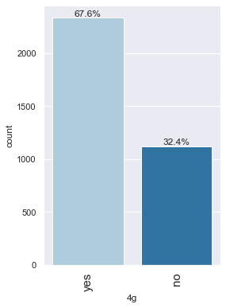

```python
labeled_barplot(df, "4g", perc=True)
```

4g is available on 67.6% of all used phones/tablets.

#### 5G

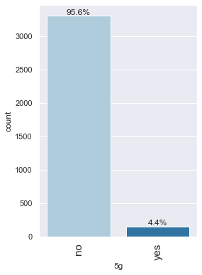

```python
labeled_barplot(df, "5g", perc=True)
```

5g is only available on 4.4% of all used phones/tablets.

#### Main Camera Megapixels

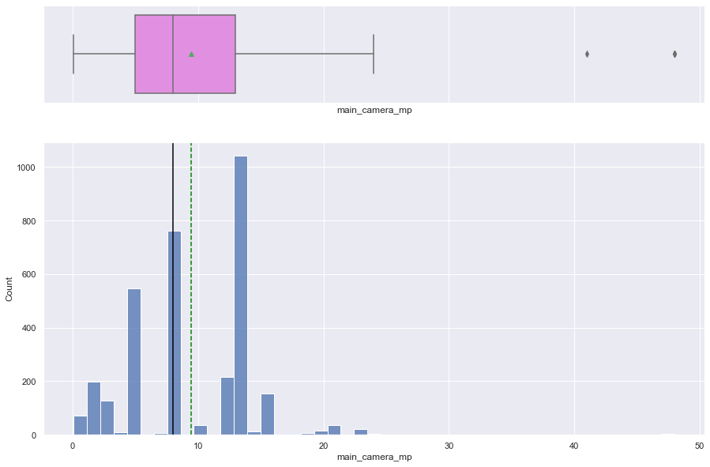

```python
histogram_boxplot(df, "main_camera_mp")
```

```python
df["main_camera_mp"].median()
```

```
8.0
```

```python
df["main_camera_mp"].max()
```

```
48.0
```

#### Selfie Camera Megapixels

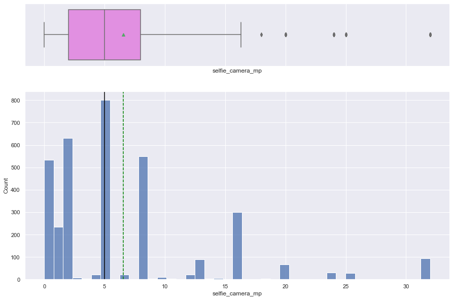

```python
histogram_boxplot(df, "selfie_camera_mp")
```

```python
df["selfie_camera_mp"].median()
```

```
5.0
```

```python
df["selfie_camera_mp"].max()
```

```
32.0
```

The median resolution on selfie cameras is 5 megapixels. The maximum is 32 megapixels.

#### Internal Memory in GB

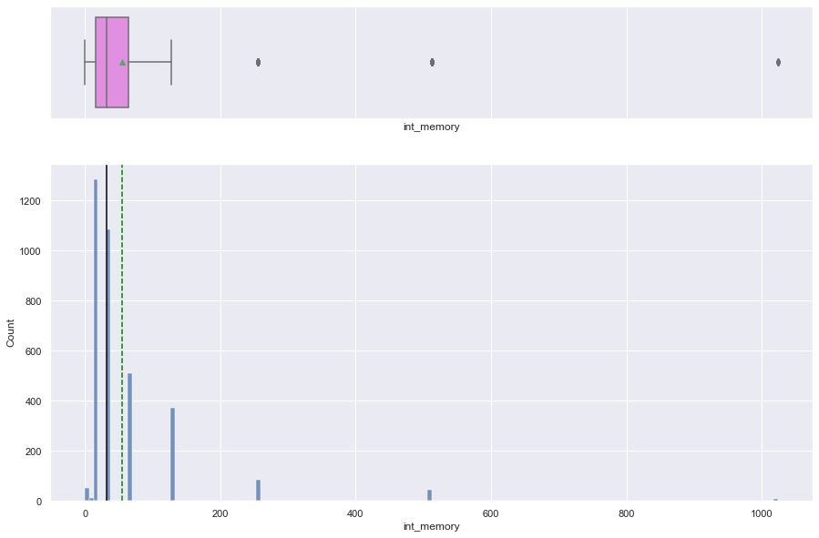

```python
histogram_boxplot(df, "int_memory")
```

```python
df["int_memory"].median()
```

```
32.0
```

```python
df["int_memory"].max()
```

```
1024.0
```

```python
df["int_memory"].min()
```

```
0.01
```

The median amount of internal memory(ROM) is 32GB.

#### Amount of RAM In GB

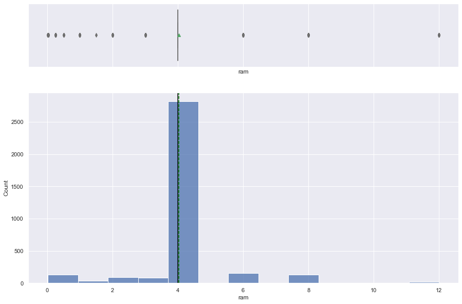

```python
histogram_boxplot(df, "ram")
```

```python
df["ram"].median()
```

```
4.0
```

```python
df["ram"].max()
```

```
12.0
```

The median amount of RAM is 4GB. The maximum is 12GB.

#### Battery Capacity in mAh

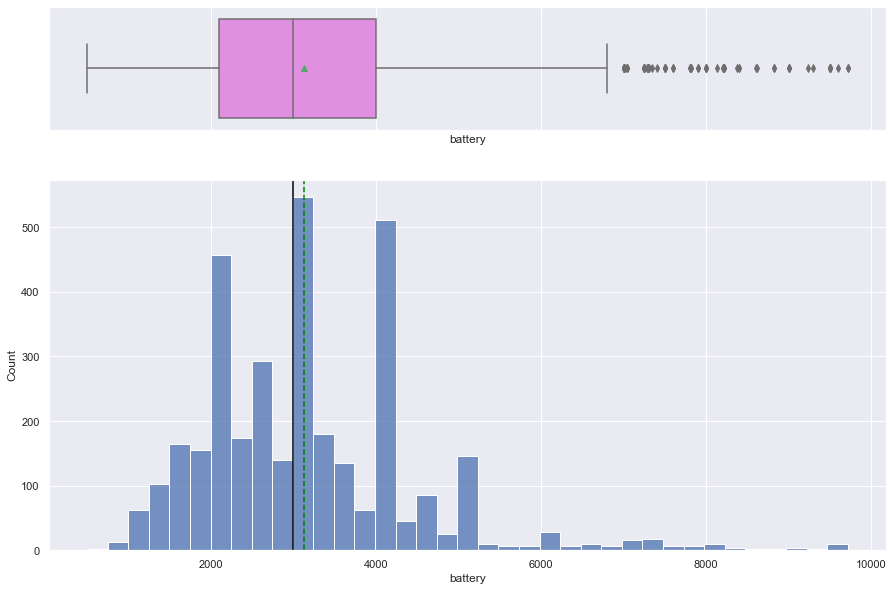

```python
histogram_boxplot(df, "battery")
```

```python
df["battery"].median()
```

```
3000.0
```

```python
df["battery"].max()
```

```
9720.0
```

```python
df["battery"].min()
```

```
500.0
```

The median battery capacity is 3000mAh. The maximum is 9720mAh and the minimum is 500mAh.

#### Weight of Device in grams

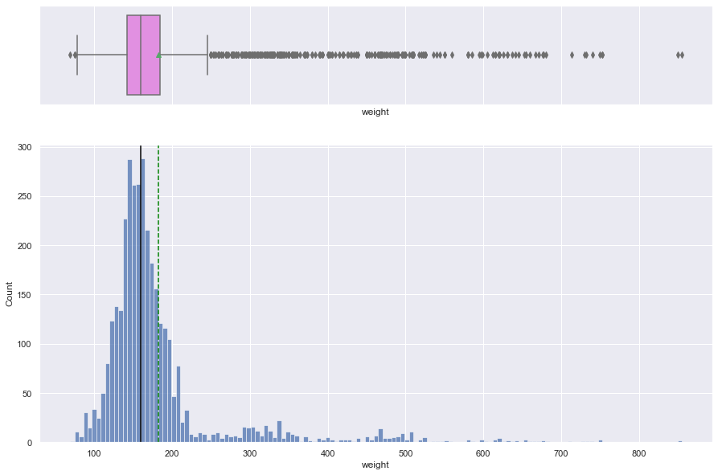

```python
histogram_boxplot(df, "weight")
```

```python
df["weight"].median()
```

```
160.0
```

```python
df["weight"].max()
```

```
855.0
```

```python
df["weight"].min()
```

```
69.0
```

The median weight of the used phones is 160 grams. The maximum is 855 grams and the minimum is 69 grams.

#### Year device was released

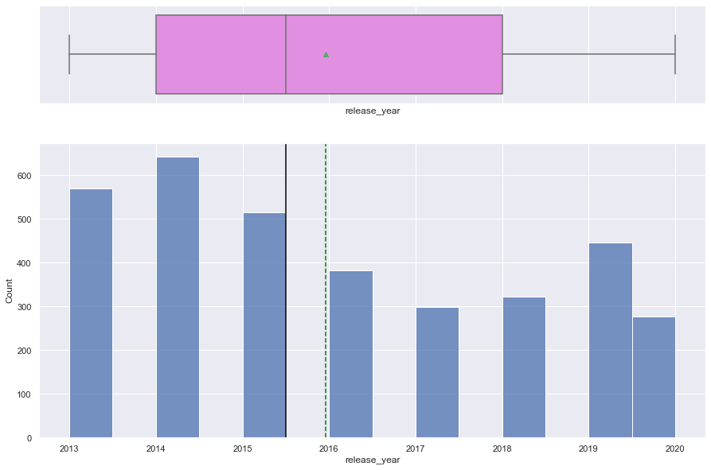

```python
histogram_boxplot(df, "release_year")
```

```python
df["release_year"].mode()
```

```
0    2014
dtype: int64
```

```python
df["release_year"].max()
```

```
2020
```

```python
df["release_year"].min()
```

```
2013
```

All of the used phones were released from 2013 to 2020.

#### Number of days device has been used

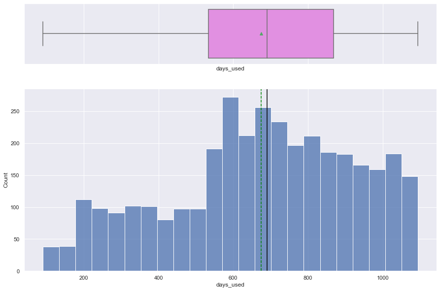

```python
histogram_boxplot(df, "days_used")
```

```python
df["days_used"].median()
```

```
690.5
```

```python
df["days_used"].max()
```

```
1094
```

```python
df["days_used"].min()
```

```
91
```

#### Normalized price of new device in euros

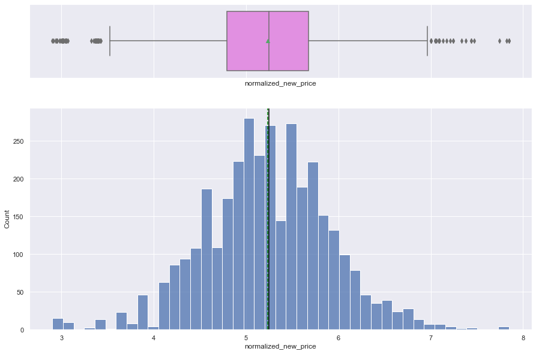

```python
histogram_boxplot(df, "normalized_new_price")
```

```python
df["normalized_new_price"].median() * 100
```

```
524.5891849370857
```

```python
df["normalized_new_price"].max() * 100
```

```
784.7840659422009
```

```python
df["normalized_new_price"].min() * 100
```

```
290.14215940827495
```

#### Normalized price of used device in Euros

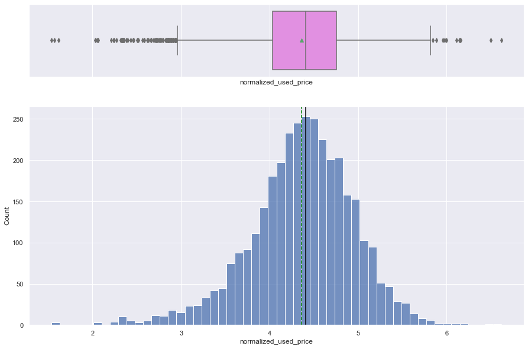

```python
histogram_boxplot(df, "normalized_used_price")
```

```python
df["normalized_used_price"].mean() * 100
```

```
436.47120791332225
```

```python
df["normalized_used_price"].max() * 100
```

```
661.9433001642933
```

```python
df["normalized_used_price"].min() * 100
```

```
153.6867219599265
```

###### Check for numerical columns that are not numerical in nature

```python
#create a list of numerical columns
num_cols=df.select_dtypes(include=np.number).columns.tolist()
num_cols
```

```
['screen_size',
 'main_camera_mp',
 'selfie_camera_mp',
 'int_memory',
 'ram',
 'battery',
 'weight',
 'release_year',
 'days_used',
 'normalized_used_price',
 'normalized_new_price']
```

```python
# drop release year since it is not numerical in nature.
num_cols.remove("release_year")
```

###### Correlation Check

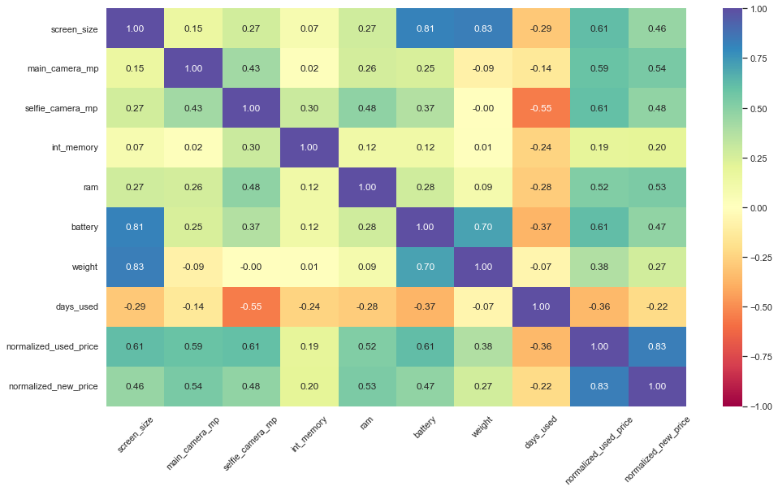

```python
plt.figure(figsize=(16, 9))
sns.heatmap(
    df[num_cols].corr(), annot=True, vmin=-1, vmax=1, fmt=".2f", cmap="Spectral"
)
plt.xticks(rotation=45)
plt.show()
```

Screen size and weight are highly correlated. Normalized used price and Normalized used price are also highly correlated.

## Question 1

What does the distribution of normalized used device prices look like?

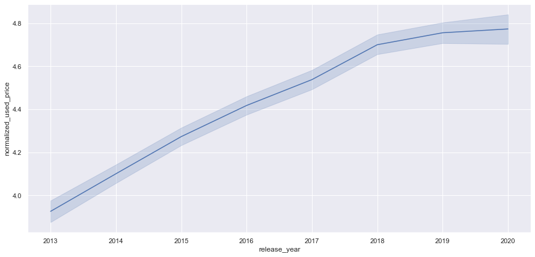

```python
plt.figure(figsize=(15, 7))
sns.lineplot(data=df, x="release_year", y="normalized_used_price")
plt.show()
```

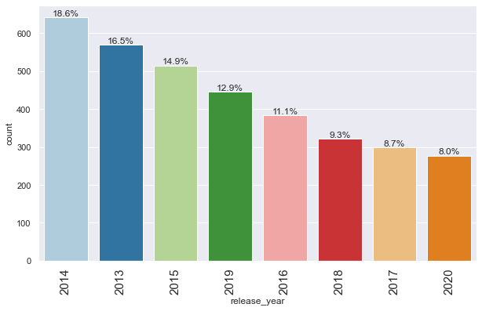

```python
plt.figure(figsize=(20, 10))
labeled_barplot(df, "release_year", perc=True)
```

The normalized used price shows a consistent increase from 2013 to 2018. However, the rate of increase starts to slow in 2018 and shows a small increase from 2019 to 2020.

## Question 2

What percentage of the used device market is dominated by Android devices?

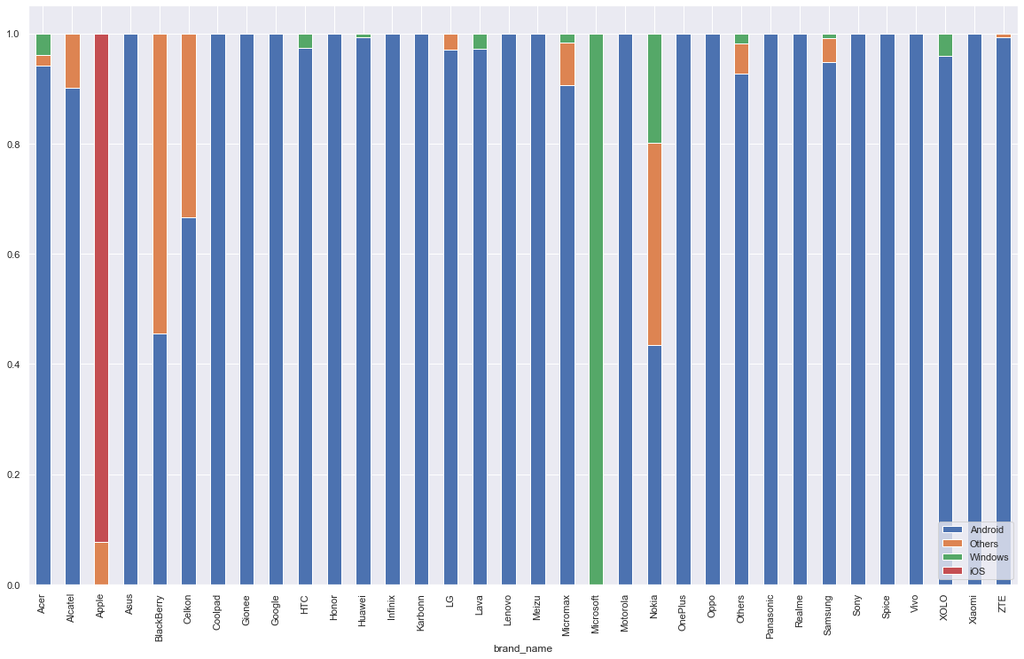

```python
pd.crosstab(df["brand_name"], df["os"], normalize="index").plot(
    kind="bar", figsize=(20, 12), stacked=True
)
plt.legend()
plt.show()
```

```python
df["os"].value_counts().sum()
```

```
3454
```

```python
df["os"].value_counts()
```

```
Android    3214
Others      137
Windows      67
iOS          36
Name: os, dtype: int64
```

```python
#There are 3214 phones wth the Android OS and a total of 3454 phones.

3214/3454
```

```
0.9305153445280834
```

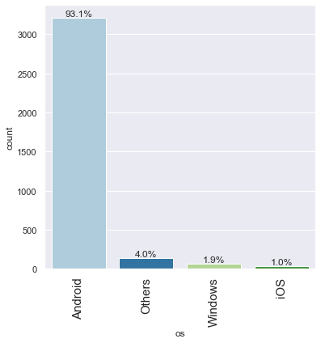

```python
plt.figure(figsize=(20, 10))
labeled_barplot(df, "os", perc=True)
```

93.1% of all used phones have the Android operating system

## Question 3

How does the amount of RAM vary with the brand?

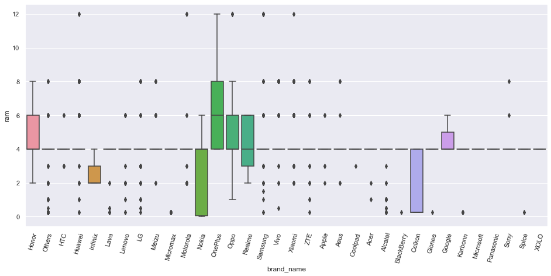

```python
plt.figure(figsize=(16, 7))
sns.boxplot(data=df, x="brand_name", y="ram")
plt.xticks(rotation=75)
plt.show()
```

```python
df["ram"].value_counts()
```

```
4.00     2815
6.00      154
8.00      130
2.00       90
0.25       83
3.00       81
1.00       34
12.00      18
0.02       18
0.03       17
0.50        9
1.50        1
Name: ram, dtype: int64
```

```python
df["ram"].max()
```

```
12.0
```

```python
df["ram"].median()
```

```
4.0
```

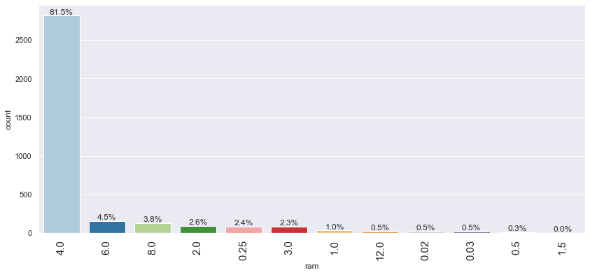

```python
plt.figure(figsize=(20, 10))
labeled_barplot(df, "ram", perc=True)
```

The brand OnePlus has the most GB of Ram on average. Honor, Oppo, and Realme also offer phones with a large a amount of RAM.

The majority of phones have 4GB of RAM. The maximum RAM is 12GB.

## Question 4

How does the weight vary for phones and tablets offering large batteries (more than 4500 mAh)?

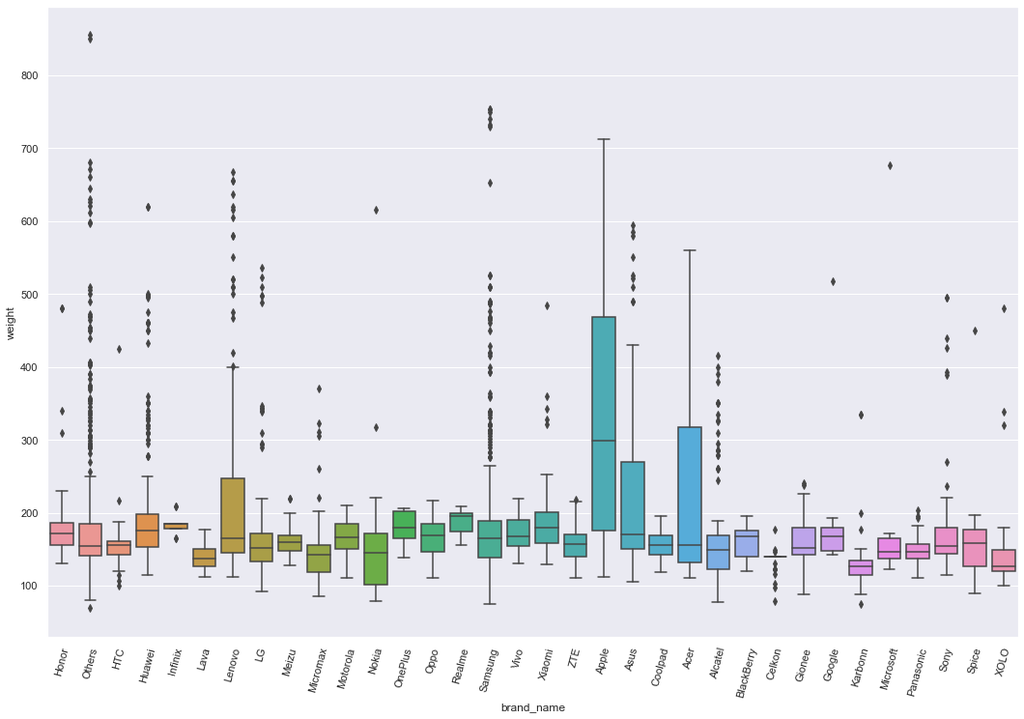

```python
plt.figure(figsize=(18, 12))
sns.boxplot(data=df, x="brand_name", y="weight")
plt.xticks(rotation=75)
plt.show()
```

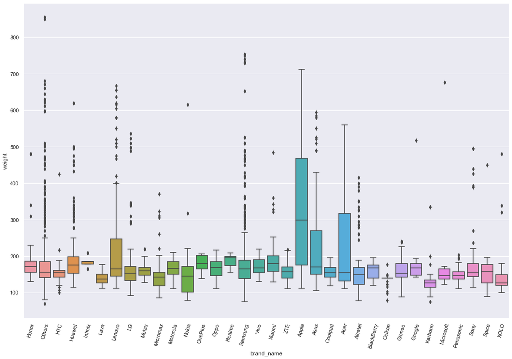

```python
plt.figure(figsize=(18, 12))
sns.boxplot(data=df, x="brand_name", y="weight")
plt.xticks(rotation=75)
plt.show()
```

```python
df_longlasting_battery = df[df.battery > 4500]
df_longlasting_battery.shape
```

```
(341, 15)
```

[figure not shown]

```python
plt.figure(figsize=(20, 10))
labeled_barplot(df_longlasting_battery, "weight", perc=True)
```

```python
df_longlasting_battery.max()
```

```
brand_name                    ZTE
os                            iOS
screen_size                 30.71
4g                            yes
5g                            yes
main_camera_mp               48.0
selfie_camera_mp             32.0
int_memory                 1024.0
ram                          12.0
battery                    9720.0
weight                      855.0
release_year                 2020
days_used                    1089
normalized_used_price    6.158969
normalized_new_price     7.090785
dtype: object
```

```python
df["battery"].max()
```

```
9720.0
```

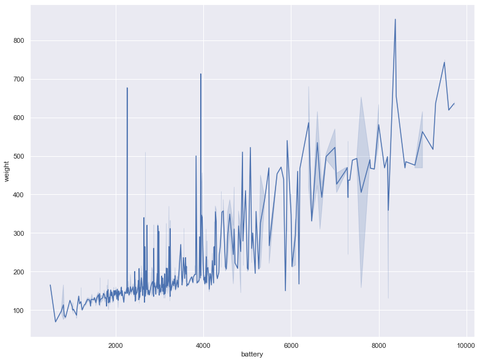

```python
plt.figure(figsize=(13, 10))
sns.lineplot(data=df, x="battery", y="weight")
```

Generally speaking, as the battery capacity increases, the weight also increases. However, batteries with mAh >4500 tend to fluctuate greatly and do not show a consistent pattern.

## Question 5

How many phones and tablets are available across different brands with a screen size larger than 6 inches?

```python
df_large_screen = df[
    df.screen_size > 15.24
]  # created large screen dataframe and converted inches to cm  (6in *2.54)
df_large_screen.shape
```

```
(1099, 15)
```

```python
df_large_screen.max()
```

```
brand_name                    ZTE
os                            iOS
screen_size                 30.71
4g                            yes
5g                            yes
main_camera_mp               48.0
selfie_camera_mp             32.0
int_memory                 1024.0
ram                          12.0
battery                    9720.0
weight                      855.0
release_year                 2020
days_used                    1090
normalized_used_price    6.619433
normalized_new_price     7.847841
dtype: object
```

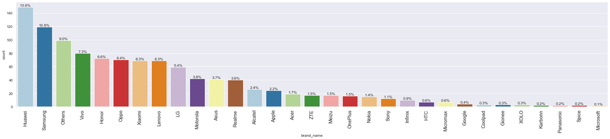

```python
plt.figure(figsize=(20, 10))
labeled_barplot(df_large_screen, "brand_name", perc=True)
```

The brand with the most phones with screen size larger than 6 inches is Huawei. Samsung has the second most.

## Question 6

What is the distribution of devices offering greater than 8 MP selfie cameras across brands?

```python
df_large_selfie_camera = df[df.selfie_camera_mp > 8]
df_large_selfie_camera.shape
```

```
(655, 15)
```

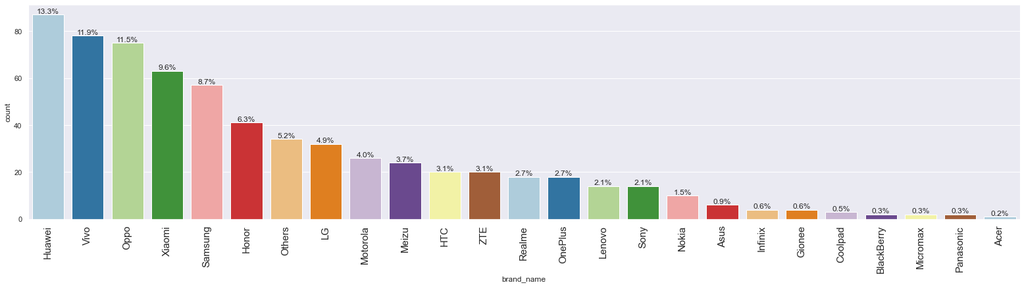

```python
plt.figure(figsize=(20, 10))
labeled_barplot(df_large_selfie_camera, "brand_name", perc=True)
```

The brand with the most phones greater than 8 megapixels is Huawei. The second most is Vivo.

## Question 7

Which attributes are highly correlated with the normalized price of a used device

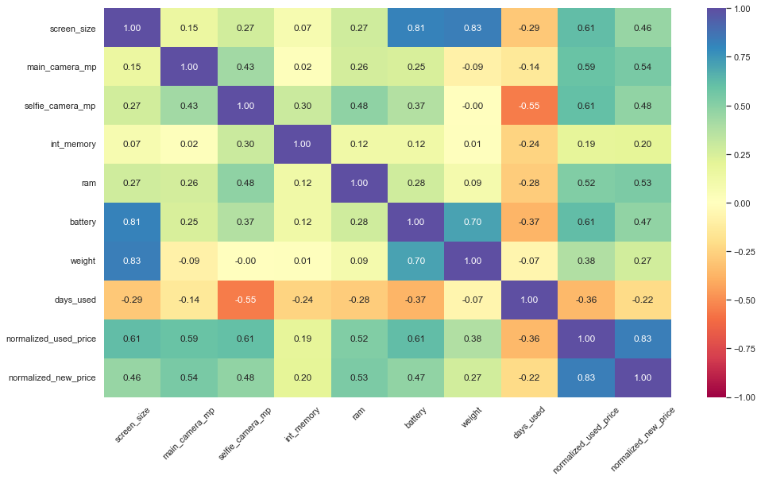

```python
plt.figure(figsize=(16, 9))
sns.heatmap(
    df[num_cols].corr(), annot=True, vmin=-1, vmax=1, fmt=".2f", cmap="Spectral"
)
plt.xticks(rotation=45)
plt.show()
```

The highest correlated attribute to normalized used price is normalized new price. Other highly correlated attributes are screen size, selfie camera mp, battery, and main camera mp.

## Data Preprocessing

- Missing value treatment
- Feature engineering (if needed)
- Outlier detection and treatment (if needed)
- Preparing data for modeling
- Any other preprocessing steps (if needed)

##### Missing value treatment

```python
df.isnull().sum()
```

```
brand_name                 0
os                         0
screen_size                0
4g                         0
5g                         0
main_camera_mp           179
selfie_camera_mp           2
int_memory                 4
ram                        4
battery                    6
weight                     7
release_year               0
days_used                  0
normalized_used_price      0
normalized_new_price       0
dtype: int64
```

```python
# copy of the data to avoid changes to original
df1 = df.copy()
```

```python
# Since the columns with missing values also have outliers, we will use median to impute missing values

df1["main_camera_mp"] = df1["main_camera_mp"].fillna(
    value=df1.groupby(["brand_name"])["main_camera_mp"].transform("median")
)
df1.isnull().sum()
```

```
brand_name                0
os                        0
screen_size               0
4g                        0
5g                        0
main_camera_mp           10
selfie_camera_mp          2
int_memory                4
ram                       4
battery                   6
weight                    7
release_year              0
days_used                 0
normalized_used_price     0
normalized_new_price      0
dtype: int64
```

```python
df1["main_camera_mp"] = df1["main_camera_mp"].fillna(
    value=df1.groupby(["os"])["main_camera_mp"].transform("median")
)
df1.isnull().sum()
```

```
brand_name               0
os                       0
screen_size              0
4g                       0
5g                       0
main_camera_mp           0
selfie_camera_mp         2
int_memory               4
ram                      4
battery                  6
weight                   7
release_year             0
days_used                0
normalized_used_price    0
normalized_new_price     0
dtype: int64
```

```python
df1["selfie_camera_mp"] = df1["selfie_camera_mp"].fillna(
    value=df1.groupby(["brand_name"])["selfie_camera_mp"].transform("median")
)
df1.isnull().sum()
```

```
brand_name               0
os                       0
screen_size              0
4g                       0
5g                       0
main_camera_mp           0
selfie_camera_mp         0
int_memory               4
ram                      4
battery                  6
weight                   7
release_year             0
days_used                0
normalized_used_price    0
normalized_new_price     0
dtype: int64
```

```python
df1["int_memory"] = df1["int_memory"].fillna(
    value=df1.groupby(["brand_name"])["int_memory"].transform("median")
)
df1.isnull().sum()
```

```
brand_name               0
os                       0
screen_size              0
4g                       0
5g                       0
main_camera_mp           0
selfie_camera_mp         0
int_memory               0
ram                      4
battery                  6
weight                   7
release_year             0
days_used                0
normalized_used_price    0
normalized_new_price     0
dtype: int64
```

```python
df1["ram"] = df1["ram"].fillna(
    value=df1.groupby(["brand_name"])["ram"].transform("median")
)
df1.isnull().sum()
```

```
brand_name               0
os                       0
screen_size              0
4g                       0
5g                       0
main_camera_mp           0
selfie_camera_mp         0
int_memory               0
ram                      0
battery                  6
weight                   7
release_year             0
days_used                0
normalized_used_price    0
normalized_new_price     0
dtype: int64
```

```python
df1["battery"] = df1["battery"].fillna(
    value=df1.groupby(["brand_name"])["battery"].transform("median")
)
df1.isnull().sum()
```

```
brand_name               0
os                       0
screen_size              0
4g                       0
5g                       0
main_camera_mp           0
selfie_camera_mp         0
int_memory               0
ram                      0
battery                  0
weight                   7
release_year             0
days_used                0
normalized_used_price    0
normalized_new_price     0
dtype: int64
```

```python
df1["weight"] = df1["weight"].fillna(
    value=df1.groupby(["brand_name"])["weight"].transform("median")
)
df1.isnull().sum()
```

```
brand_name               0
os                       0
screen_size              0
4g                       0
5g                       0
main_camera_mp           0
selfie_camera_mp         0
int_memory               0
ram                      0
battery                  0
weight                   0
release_year             0
days_used                0
normalized_used_price    0
normalized_new_price     0
dtype: int64
```

All missing values have been treated

#### Feature Engineering

```python
df1["years_since_release"] = 2021 - df1["release_year"]
df1.drop("release_year", axis=1, inplace=True)
df1["years_since_release"].describe()
```

```
count    3454.000000
mean        5.034742
std         2.298455
min         1.000000
25%         3.000000
50%         5.500000
75%         7.000000
max         8.000000
Name: years_since_release, dtype: float64
```

#### Outlier Detection

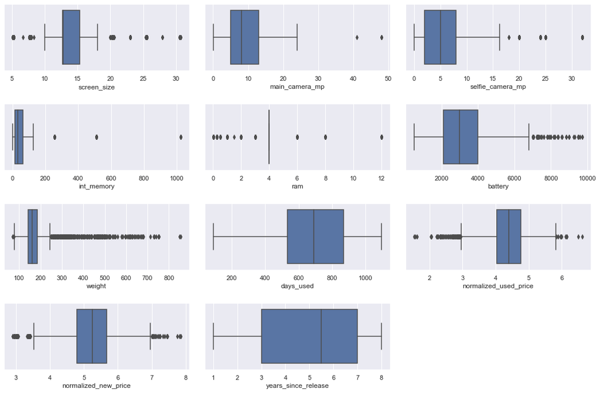

```python
num_cols = df1.select_dtypes(include=np.number).columns.tolist() #Check for outliers in the data

plt.figure(figsize=(15, 10))

for i, variable in enumerate(num_cols):
    plt.subplot(4, 3, i + 1)
    sns.boxplot(data=df1, x=variable)
    plt.tight_layout(pad=2)

plt.show()
```

Weight and battery appear to have the most outliers in the data.

#### Data Preparation for Modeling

```python
# Define X and y variables
X = df1.drop(["normalized_used_price"], axis=1)
y = df1["normalized_used_price"]

print(X.head())
print(y.head())
```

```
  brand_name       os  screen_size   4g   5g  main_camera_mp  \
0      Honor  Android        14.50  yes   no            13.0
1      Honor  Android        17.30  yes  yes            13.0
2      Honor  Android        16.69  yes  yes            13.0
3      Honor  Android        25.50  yes  yes            13.0
4      Honor  Android        15.32  yes   no            13.0

   selfie_camera_mp  int_memory  ram  battery  weight  days_used  \
0               5.0        64.0  3.0   3020.0   146.0        127
1              16.0       128.0  8.0   4300.0   213.0        325
2               8.0       128.0  8.0   4200.0   213.0        162
3               8.0        64.0  6.0   7250.0   480.0        345
4               8.0        64.0  3.0   5000.0   185.0        293

   normalized_new_price  years_since_release
0              4.715100                    1
1              5.519018                    1
2              5.884631                    1
3              5.630961                    1
4              4.947837                    1
0    4.307572
1    5.162097
2    5.111084
3    5.135387
4    4.389995
Name: normalized_used_price, dtype: float64
```

```python
# Add the intercept to data
X = sm.add_constant(X)
```

```python
# Create dummy variables
X = pd.get_dummies(
    X,
    columns=X.select_dtypes(include=["object", "category"]).columns.tolist(),
    drop_first=True,
)
X.head()
```

|  | const | screen_size | main_camera_mp | selfie_camera_mp | int_memory | ram | battery | weight | days_used | normalized_new_price | ... | brand_name_Spice | brand_name_Vivo | brand_name_XOLO | brand_name_Xiaomi | brand_name_ZTE | os_Others | os_Windows | os_iOS | 4g_yes | 5g_yes |
| --- | --- | --- | --- | --- | --- | --- | --- | --- | --- | --- | --- | --- | --- | --- | --- | --- | --- | --- | --- | --- | --- |
| 0 | 1.0 | 14.50 | 13.0 | 5.0 | 64.0 | 3.0 | 3020.0 | 146.0 | 127 | 4.715100 | ... | 0 | 0 | 0 | 0 | 0 | 0 | 0 | 0 | 1 | 0 |
| 1 | 1.0 | 17.30 | 13.0 | 16.0 | 128.0 | 8.0 | 4300.0 | 213.0 | 325 | 5.519018 | ... | 0 | 0 | 0 | 0 | 0 | 0 | 0 | 0 | 1 | 1 |
| 2 | 1.0 | 16.69 | 13.0 | 8.0 | 128.0 | 8.0 | 4200.0 | 213.0 | 162 | 5.884631 | ... | 0 | 0 | 0 | 0 | 0 | 0 | 0 | 0 | 1 | 1 |
| 3 | 1.0 | 25.50 | 13.0 | 8.0 | 64.0 | 6.0 | 7250.0 | 480.0 | 345 | 5.630961 | ... | 0 | 0 | 0 | 0 | 0 | 0 | 0 | 0 | 1 | 1 |
| 4 | 1.0 | 15.32 | 13.0 | 8.0 | 64.0 | 3.0 | 5000.0 | 185.0 | 293 | 4.947837 | ... | 0 | 0 | 0 | 0 | 0 | 0 | 0 | 0 | 1 | 0 |

5 rows × 49 columns

```python
#Splitting data in 70:30 ratio for train to test data

x_train, x_test, y_train, y_test=train_test_split(X,y,test_size=0.3, random_state=1)
```

```python
print("Number of rows in train data=", x_train.shape[0])
print("Number of rows in test data=", x_test.shape[0])
```

```
Number of rows in train data= 2417
Number of rows in test data= 1037
```

## EDA

- It is a good idea to explore the data once again after manipulating it.

```python
df1.info()
```

```
<class 'pandas.core.frame.DataFrame'>
RangeIndex: 3454 entries, 0 to 3453
Data columns (total 15 columns):
 #   Column                 Non-Null Count  Dtype
---  ------                 --------------  -----
 0   brand_name             3454 non-null   object
 1   os                     3454 non-null   object
 2   screen_size            3454 non-null   float64
 3   4g                     3454 non-null   object
 4   5g                     3454 non-null   object
 5   main_camera_mp         3454 non-null   float64
 6   selfie_camera_mp       3454 non-null   float64
 7   int_memory             3454 non-null   float64
 8   ram                    3454 non-null   float64
 9   battery                3454 non-null   float64
 10  weight                 3454 non-null   float64
 11  days_used              3454 non-null   int64
 12  normalized_used_price  3454 non-null   float64
 13  normalized_new_price   3454 non-null   float64
 14  years_since_release    3454 non-null   int64
dtypes: float64(9), int64(2), object(4)
memory usage: 404.9+ KB
```

```python
df1.describe().T
```

|  | count | mean | std | min | 25% | 50% | 75% | max |
| --- | --- | --- | --- | --- | --- | --- | --- | --- |
| screen_size | 3454.0 | 13.713115 | 3.805280 | 5.080000 | 12.700000 | 12.830000 | 15.340000 | 30.710000 |
| main_camera_mp | 3454.0 | 9.629178 | 4.750356 | 0.080000 | 5.000000 | 8.100000 | 13.000000 | 48.000000 |
| selfie_camera_mp | 3454.0 | 6.555067 | 6.968440 | 0.000000 | 2.000000 | 5.000000 | 8.000000 | 32.000000 |
| int_memory | 3454.0 | 54.528428 | 84.933275 | 0.010000 | 16.000000 | 32.000000 | 64.000000 | 1024.000000 |
| ram | 3454.0 | 4.036080 | 1.364314 | 0.020000 | 4.000000 | 4.000000 | 4.000000 | 12.000000 |
| battery | 3454.0 | 3132.577446 | 1298.884193 | 500.000000 | 2100.000000 | 3000.000000 | 4000.000000 | 9720.000000 |
| weight | 3454.0 | 182.636856 | 88.360445 | 69.000000 | 142.000000 | 160.000000 | 185.000000 | 855.000000 |
| days_used | 3454.0 | 674.869716 | 248.580166 | 91.000000 | 533.500000 | 690.500000 | 868.750000 | 1094.000000 |
| normalized_used_price | 3454.0 | 4.364712 | 0.588914 | 1.536867 | 4.033931 | 4.405133 | 4.755700 | 6.619433 |
| normalized_new_price | 3454.0 | 5.233107 | 0.683637 | 2.901422 | 4.790342 | 5.245892 | 5.673718 | 7.847841 |
| years_since_release | 3454.0 | 5.034742 | 2.298455 | 1.000000 | 3.000000 | 5.500000 | 7.000000 | 8.000000 |

```python
df1.isnull().sum()
```

```
brand_name               0
os                       0
screen_size              0
4g                       0
5g                       0
main_camera_mp           0
selfie_camera_mp         0
int_memory               0
ram                      0
battery                  0
weight                   0
days_used                0
normalized_used_price    0
normalized_new_price     0
years_since_release      0
dtype: int64
```

## Model Building - Linear Regression

```python
olsmodel = sm.OLS(y_train, x_train).fit()
print(olsmodel.summary())
```

```
                              OLS Regression Results
=================================================================================
Dep. Variable:     normalized_used_price   R-squared:                       0.845
Model:                               OLS   Adj. R-squared:                  0.842
Method:                    Least Squares   F-statistic:                     268.8
Date:                   Thu, 07 Jul 2022   Prob (F-statistic):               0.00
Time:                           11:51:11   Log-Likelihood:                 124.15
No. Observations:                   2417   AIC:                            -150.3
Df Residuals:                       2368   BIC:                             133.4
Df Model:                             48
Covariance Type:               nonrobust
=========================================================================================
                            coef    std err          t      P>|t|      [0.025      0.975]
-----------------------------------------------------------------------------------------
const                     1.3158      0.071     18.461      0.000       1.176       1.456
screen_size               0.0244      0.003      7.156      0.000       0.018       0.031
main_camera_mp            0.0208      0.002     13.848      0.000       0.018       0.024
selfie_camera_mp          0.0135      0.001     11.996      0.000       0.011       0.016
int_memory                0.0001   6.97e-05      1.664      0.096   -2.07e-05       0.000
ram                       0.0232      0.005      4.515      0.000       0.013       0.033
battery               -1.686e-05   7.27e-06     -2.318      0.021   -3.11e-05    -2.6e-06
weight                    0.0010      0.000      7.488      0.000       0.001       0.001
days_used              4.196e-05   3.09e-05      1.360      0.174   -1.85e-05       0.000
normalized_new_price      0.4309      0.012     35.134      0.000       0.407       0.455
years_since_release      -0.0236      0.005     -5.189      0.000      -0.033      -0.015
brand_name_Alcatel        0.0154      0.048      0.324      0.746      -0.078       0.109
brand_name_Apple         -0.0032      0.147     -0.021      0.983      -0.292       0.285
brand_name_Asus           0.0150      0.048      0.313      0.754      -0.079       0.109
brand_name_BlackBerry    -0.0297      0.070     -0.423      0.672      -0.167       0.108
brand_name_Celkon        -0.0463      0.066     -0.699      0.484      -0.176       0.084
brand_name_Coolpad        0.0209      0.073      0.286      0.775      -0.122       0.164
brand_name_Gionee         0.0447      0.058      0.775      0.438      -0.068       0.158
brand_name_Google        -0.0327      0.085     -0.386      0.700      -0.199       0.133
brand_name_HTC           -0.0131      0.048     -0.271      0.786      -0.108       0.081
brand_name_Honor          0.0316      0.049      0.642      0.521      -0.065       0.128
brand_name_Huawei        -0.0022      0.044     -0.049      0.961      -0.089       0.085
brand_name_Infinix        0.0801      0.093      0.859      0.390      -0.103       0.263
brand_name_Karbonn        0.0943      0.067      1.406      0.160      -0.037       0.226
brand_name_LG            -0.0132      0.045     -0.292      0.771      -0.102       0.076
brand_name_Lava           0.0332      0.062      0.533      0.594      -0.089       0.155
```

[output cut: 19 more lines]

```
os_Windows               -0.0202      0.045     -0.448      0.654      -0.109       0.068
os_iOS                   -0.0669      0.146     -0.457      0.648      -0.354       0.220
4g_yes                    0.0530      0.016      3.341      0.001       0.022       0.084
5g_yes                   -0.0721      0.031     -2.292      0.022      -0.134      -0.010
==============================================================================
Omnibus:                      223.220   Durbin-Watson:                   1.911
Prob(Omnibus):                  0.000   Jarque-Bera (JB):              422.514
Skew:                          -0.618   Prob(JB):                     1.79e-92
Kurtosis:                       4.633   Cond. No.                     1.78e+05
==============================================================================

Notes:
[1] Standard Errors assume that the covariance matrix of the errors is correctly specified.
[2] The condition number is large, 1.78e+05. This might indicate that there are
strong multicollinearity or other numerical problems.
```

#### Model Performance Check

```python
# Function to compute adjusted R-squared
def adj_r2_score(predictors, targets, predictions):
    r2 = r2_score(targets, predictions)
    n = predictors.shape[0]
    k = predictors.shape[1]
    return 1 - ((1 - r2) * (n - 1) / (n - k - 1))


# function to compute MAPE
def mape_score(targets, predictions):
    return np.mean(np.abs(targets - predictions) / targets) * 100


# function to compute different metrics to check performance of a regression model
def model_performance_regression(model, predictors, target):
    """Function to compute different metrics to check regression model performance
    model:regressor
    predictors: independent variables
    target: dependent variable"""

    # predicting using the independent variables
    pred = model.predict(predictors)

    r2 = r2_score(target, pred)  # computing R-squared
    adjr2 = adj_r2_score(predictors, target, pred)  # computing adjusted R-squared
    rmse = np.sqrt(mean_squared_error(target, pred))  # computing RMSE
    mae = mean_absolute_error(target, pred)  # computing MAE
    mape = mape_score(target, pred)  # computing MAPE

    # create a dataframe for metrics
    df_perf = pd.DataFrame(
        {
            "RMSE": rmse,
            "MAE": mae,
            "R-squared": r2,
            "Adj. R-squared": adjr2,
            "MAPE": mape,
        },
        index=[0],
    )

    return df_perf
```

```python
# Checking model performance on train set (70% data)
print("Training Performance\n")
olsmodel_train_perf = model_performance_regression(olsmodel, x_train, y_train)
olsmodel_train_perf
```

```
Training Performance
```

|  | RMSE | MAE | R-squared | Adj. R-squared | MAPE |
| --- | --- | --- | --- | --- | --- |
| 0 | 0.229856 | 0.180302 | 0.844924 | 0.841713 | 4.326213 |

```python
# Checking model performance on test set (30% data)

print("Test Performance\n")
olsmodel_test_perf = model_performance_regression(olsmodel, x_test, y_test)
olsmodel_test_perf
```

```
Test Performance
```

|  | RMSE | MAE | R-squared | Adj. R-squared | MAPE |
| --- | --- | --- | --- | --- | --- |
| 0 | 0.238482 | 0.184868 | 0.842315 | 0.834487 | 4.505694 |

##### Observations

Train and test RMSE and MAE are comparable indicating that the model is not overfitting.

MAE suggests that the model can predict the price of a used phone/tablet within a mean error of 0.18 on the test data.

MAPE of 4.5 on the test data means that we are able to predict within 4.5% of the price of a used phone/tablet.

## Checking Linear Regression Assumptions

- In order to make statistical inferences from a linear regression model, it is important to ensure that the assumptions of linear regression are satisfied.

#### Test for Multicollinearity

```python
from statsmodels.stats.outliers_influence import variance_inflation_factor


def checking_vif(predictors):
    vif = pd.DataFrame()
    vif["feature"] = predictors.columns

    # Calculating VIF for each feature
    vif["VIF"] = [
        variance_inflation_factor(predictors.values, i)
        for i in range(len(predictors.columns))
    ]
    return vif
```

```python
checking_vif(x_train)
```

|  | feature | VIF |
| --- | --- | --- |
| 0 | const | 227.678565 |
| 1 | screen_size | 7.677118 |
| 2 | main_camera_mp | 2.285811 |
| 3 | selfie_camera_mp | 2.810716 |
| 4 | int_memory | 1.364057 |
| 5 | ram | 2.255246 |
| 6 | battery | 4.081715 |
| 7 | weight | 6.397183 |
| 8 | days_used | 2.660002 |
| 9 | normalized_new_price | 3.119569 |
| 10 | years_since_release | 4.898360 |
| 11 | brand_name_Alcatel | 3.405674 |
| 12 | brand_name_Apple | 13.054832 |
| 13 | brand_name_Asus | 3.332003 |
| 14 | brand_name_BlackBerry | 1.632250 |
| 15 | brand_name_Celkon | 1.774820 |
| 16 | brand_name_Coolpad | 1.467981 |
| 17 | brand_name_Gionee | 1.951247 |
| 18 | brand_name_Google | 1.321771 |
| 19 | brand_name_HTC | 3.410252 |
| 20 | brand_name_Honor | 3.340621 |
| 21 | brand_name_Huawei | 5.983857 |
| 22 | brand_name_Infinix | 1.285635 |
| 23 | brand_name_Karbonn | 1.573683 |
| 24 | brand_name_LG | 4.849589 |
| 25 | brand_name_Lava | 1.711317 |
| 26 | brand_name_Lenovo | 4.558847 |
| 27 | brand_name_Meizu | 2.179607 |
| 28 | brand_name_Micromax | 3.363518 |
| 29 | brand_name_Microsoft | 1.869558 |
| 30 | brand_name_Motorola | 3.274455 |
| 31 | brand_name_Nokia | 3.473140 |
| 32 | brand_name_OnePlus | 1.437047 |
| 33 | brand_name_Oppo | 3.971065 |
| 34 | brand_name_Others | 9.710921 |
| 35 | brand_name_Panasonic | 2.105711 |
| 36 | brand_name_Realme | 1.946675 |
| 37 | brand_name_Samsung | 7.539832 |
| 38 | brand_name_Sony | 2.943127 |
| 39 | brand_name_Spice | 1.688868 |
| 40 | brand_name_Vivo | 3.651320 |
| 41 | brand_name_XOLO | 2.138074 |
| 42 | brand_name_Xiaomi | 3.719678 |
| 43 | brand_name_ZTE | 3.797527 |
| 44 | os_Others | 1.854134 |
| 45 | os_Windows | 1.595291 |
| 46 | os_iOS | 11.780766 |
| 47 | 4g_yes | 2.468374 |
| 48 | 5g_yes | 1.811042 |

There are multiple columns with VIF values >5 indicating strong multicollinearity. We will drop the numerical columns

We will also ignore the VIF values for dummy variables and the constant(intercept).

```python
def treating_multicollinearity(predictors, target, high_vif_columns):
    """
    Checking the effect of dropping the columns showing high multicollinearity
    on model performance (adj. R-squared and RMSE)

    predictors: independent variables
    target: dependent variable
    high_vif_columns: columns having high VIF
    """
    # empty lists to store adj. R-squared and RMSE values
    adj_r2 = []
    rmse = []

    # build ols models by dropping one of the high VIF columns at a time
    # store the adjusted R-squared and RMSE in the lists defined previously
    for cols in high_vif_columns:
        # defining the new train set
        train = predictors.loc[:, ~predictors.columns.str.startswith(cols)]

        # create the model
        olsmodel = sm.OLS(target, train).fit()

        # adding adj. R-squared and RMSE to the lists
        adj_r2.append(olsmodel.rsquared_adj)
        rmse.append(np.sqrt(olsmodel.mse_resid))

    # creating a dataframe for the results
    temp = pd.DataFrame(
        {
            "col": high_vif_columns,
            "Adj. R-squared after_dropping col": adj_r2,
            "RMSE after dropping col": rmse,
        }
    ).sort_values(by="Adj. R-squared after_dropping col", ascending=False)
    temp.reset_index(drop=True, inplace=True)

    return temp
```

```python
col_list = ["screen_size", "weight"]

res = treating_multicollinearity(x_train, y_train, col_list)
res
```

|  | col | Adj. R-squared after_dropping col | RMSE after dropping col |
| --- | --- | --- | --- |
| 0 | screen_size | 0.838427 | 0.234670 |
| 1 | weight | 0.838102 | 0.234906 |

```python
# Dropping weight column
col_to_drop = "weight"
x_train2 = x_train.loc[:, ~x_train.columns.str.startswith(col_to_drop)]
x_test2 = x_test.loc[:, ~x_test.columns.str.startswith(col_to_drop)]

# Rechecking VIF after dropping weight
vif = checking_vif(x_train2)
print("VIF after dropping", col_to_drop)
vif
```

```
VIF after dropping weight
```

|  | feature | VIF |
| --- | --- | --- |
| 0 | const | 208.922580 |
| 1 | screen_size | 3.592842 |
| 2 | main_camera_mp | 2.189497 |
| 3 | selfie_camera_mp | 2.786299 |
| 4 | int_memory | 1.363914 |
| 5 | ram | 2.253162 |
| 6 | battery | 3.681148 |
| 7 | days_used | 2.648007 |
| 8 | normalized_new_price | 3.116373 |
| 9 | years_since_release | 4.726162 |
| 10 | brand_name_Alcatel | 3.405614 |
| 11 | brand_name_Apple | 13.049255 |
| 12 | brand_name_Asus | 3.329491 |
| 13 | brand_name_BlackBerry | 1.632202 |
| 14 | brand_name_Celkon | 1.774351 |
| 15 | brand_name_Coolpad | 1.467907 |
| 16 | brand_name_Gionee | 1.951199 |
| 17 | brand_name_Google | 1.321649 |
| 18 | brand_name_HTC | 3.408324 |
| 19 | brand_name_Honor | 3.339001 |
| 20 | brand_name_Huawei | 5.983687 |
| 21 | brand_name_Infinix | 1.285040 |
| 22 | brand_name_Karbonn | 1.573602 |
| 23 | brand_name_LG | 4.848760 |
| 24 | brand_name_Lava | 1.711094 |
| 25 | brand_name_Lenovo | 4.557480 |
| 26 | brand_name_Meizu | 2.179174 |
| 27 | brand_name_Micromax | 3.363420 |
| 28 | brand_name_Microsoft | 1.867493 |
| 29 | brand_name_Motorola | 3.269448 |
| 30 | brand_name_Nokia | 3.467817 |
| 31 | brand_name_OnePlus | 1.436755 |
| 32 | brand_name_Oppo | 3.971041 |
| 33 | brand_name_Others | 9.680222 |
| 34 | brand_name_Panasonic | 2.105695 |
| 35 | brand_name_Realme | 1.946643 |
| 36 | brand_name_Samsung | 7.537301 |
| 37 | brand_name_Sony | 2.939129 |
| 38 | brand_name_Spice | 1.687000 |
| 39 | brand_name_Vivo | 3.650605 |
| 40 | brand_name_XOLO | 2.136751 |
| 41 | brand_name_Xiaomi | 3.719672 |
| 42 | brand_name_ZTE | 3.795567 |
| 43 | os_Others | 1.739066 |
| 44 | os_Windows | 1.595291 |
| 45 | os_iOS | 11.746983 |
| 46 | 4g_yes | 2.448407 |
| 47 | 5g_yes | 1.808867 |

Dropping weight eliminated the multicollinearity issue for all non-dummy variables.

```python
olsmod1 = sm.OLS(y_train, x_train2).fit()
print(olsmod1.summary())
```

```
                              OLS Regression Results
=================================================================================
Dep. Variable:     normalized_used_price   R-squared:                       0.841
Model:                               OLS   Adj. R-squared:                  0.838
Method:                    Least Squares   F-statistic:                     267.1
Date:                   Thu, 07 Jul 2022   Prob (F-statistic):               0.00
Time:                           11:51:12   Log-Likelihood:                 95.864
No. Observations:                   2417   AIC:                            -95.73
Df Residuals:                       2369   BIC:                             182.2
Df Model:                             47
Covariance Type:               nonrobust
=========================================================================================
                            coef    std err          t      P>|t|      [0.025      0.975]
-----------------------------------------------------------------------------------------
const                     1.1626      0.069     16.834      0.000       1.027       1.298
screen_size               0.0430      0.002     18.234      0.000       0.038       0.048
main_camera_mp            0.0185      0.001     12.435      0.000       0.016       0.021
selfie_camera_mp          0.0127      0.001     11.218      0.000       0.010       0.015
int_memory                0.0001   7.05e-05      1.569      0.117   -2.77e-05       0.000
ram                       0.0220      0.005      4.240      0.000       0.012       0.032
battery                 2.02e-07   6.99e-06      0.029      0.977   -1.35e-05    1.39e-05
days_used              5.748e-05   3.11e-05      1.846      0.065   -3.59e-06       0.000
normalized_new_price      0.4338      0.012     34.988      0.000       0.410       0.458
years_since_release      -0.0172      0.005     -3.809      0.000      -0.026      -0.008
brand_name_Alcatel        0.0139      0.048      0.290      0.772      -0.080       0.108
brand_name_Apple         -0.0259      0.149     -0.174      0.862      -0.318       0.266
brand_name_Asus           0.0249      0.048      0.513      0.608      -0.070       0.120
brand_name_BlackBerry    -0.0269      0.071     -0.379      0.705      -0.166       0.112
brand_name_Celkon        -0.0383      0.067     -0.571      0.568      -0.170       0.093
brand_name_Coolpad        0.0247      0.074      0.336      0.737      -0.120       0.169
brand_name_Gionee         0.0426      0.058      0.729      0.466      -0.072       0.157
brand_name_Google        -0.0266      0.086     -0.311      0.756      -0.194       0.141
brand_name_HTC           -0.0045      0.049     -0.092      0.926      -0.100       0.091
brand_name_Honor          0.0235      0.050      0.472      0.637      -0.074       0.121
brand_name_Huawei        -0.0004      0.045     -0.009      0.993      -0.089       0.088
brand_name_Infinix        0.0651      0.094      0.690      0.490      -0.120       0.250
brand_name_Karbonn        0.0907      0.068      1.336      0.182      -0.042       0.224
brand_name_LG            -0.0088      0.046     -0.192      0.848      -0.099       0.081
brand_name_Lava           0.0279      0.063      0.442      0.659      -0.096       0.151
brand_name_Lenovo         0.0512      0.046      1.119      0.263      -0.038       0.141
```

[output cut: 18 more lines]

```
os_Windows               -0.0202      0.046     -0.443      0.658      -0.110       0.069
os_iOS                   -0.0082      0.148     -0.056      0.956      -0.298       0.282
4g_yes                    0.0423      0.016      2.648      0.008       0.011       0.074
5g_yes                   -0.0640      0.032     -2.010      0.045      -0.126      -0.002
==============================================================================
Omnibus:                      209.742   Durbin-Watson:                   1.917
Prob(Omnibus):                  0.000   Jarque-Bera (JB):              379.261
Skew:                          -0.602   Prob(JB):                     4.41e-83
Kurtosis:                       4.523   Cond. No.                     1.78e+05
==============================================================================

Notes:
[1] Standard Errors assume that the covariance matrix of the errors is correctly specified.
[2] The condition number is large, 1.78e+05. This might indicate that there are
strong multicollinearity or other numerical problems.
```

#### Dealing with high p-value variables

```python
#list of columns
predictors=x_train2.copy()
cols=predictors.columns.tolist()

#set up initial max p-value
max_p_value=1

while len(cols)>0:
    #define train set
    x_train_aux=predictors[cols]

    #fitting the model
    model=sm.OLS(y_train, x_train_aux).fit()

    #calculating p-values and maxmimum p-value
    p_values=model.pvalues
    max_p_value=max(p_values)

    #name of variable with maximum p-value
    feature_with_p_max=p_values.idxmax()

    if max_p_value >0.05:
        cols.remove(feature_with_p_max)
    else:
        break

selected_features=cols
print(selected_features)
```

```
['const', 'screen_size', 'main_camera_mp', 'selfie_camera_mp', 'ram', 'days_used', 'normalized_new_price', 'years_since_release', 'brand_name_Lenovo', 'brand_name_Nokia', 'brand_name_Xiaomi', '4g_yes']
```

```python
x_train3 = x_train2[selected_features]
x_test3 = x_test2[selected_features]
```

```python
olsmod2 = sm.OLS(y_train, x_train3).fit()
print(olsmod2.summary())
```

```
                              OLS Regression Results
=================================================================================
Dep. Variable:     normalized_used_price   R-squared:                       0.839
Model:                               OLS   Adj. R-squared:                  0.839
Method:                    Least Squares   F-statistic:                     1143.
Date:                   Thu, 07 Jul 2022   Prob (F-statistic):               0.00
Time:                           11:51:13   Log-Likelihood:                 82.276
No. Observations:                   2417   AIC:                            -140.6
Df Residuals:                       2405   BIC:                            -71.07
Df Model:                             11
Covariance Type:               nonrobust
========================================================================================
                           coef    std err          t      P>|t|      [0.025      0.975]
----------------------------------------------------------------------------------------
const                    1.2074      0.046     26.209      0.000       1.117       1.298
screen_size              0.0432      0.002     28.318      0.000       0.040       0.046
main_camera_mp           0.0190      0.001     14.019      0.000       0.016       0.022
selfie_camera_mp         0.0131      0.001     12.353      0.000       0.011       0.015
ram                      0.0177      0.004      4.022      0.000       0.009       0.026
days_used             6.297e-05   3.03e-05      2.077      0.038    3.51e-06       0.000
normalized_new_price     0.4283      0.011     39.663      0.000       0.407       0.449
years_since_release     -0.0179      0.004     -4.144      0.000      -0.026      -0.009
brand_name_Lenovo        0.0492      0.022      2.277      0.023       0.007       0.092
brand_name_Nokia         0.0734      0.030      2.468      0.014       0.015       0.132
brand_name_Xiaomi        0.0855      0.026      3.336      0.001       0.035       0.136
4g_yes                   0.0366      0.015      2.438      0.015       0.007       0.066
==============================================================================
Omnibus:                      215.934   Durbin-Watson:                   1.915
Prob(Omnibus):                  0.000   Jarque-Bera (JB):              402.040
Skew:                          -0.607   Prob(JB):                     4.99e-88
Kurtosis:                       4.588   Cond. No.                     7.12e+03
==============================================================================

Notes:
[1] Standard Errors assume that the covariance matrix of the errors is correctly specified.
[2] The condition number is large, 7.12e+03. This might indicate that there are
strong multicollinearity or other numerical problems.
```

```python
# Check model performance on train set (70% data)
print("Training Performance\n")
olsmod2_train_perf = model_performance_regression(olsmod2, x_train3, y_train)
olsmod2_train_perf
```

```
Training Performance
```

|  | RMSE | MAE | R-squared | Adj. R-squared | MAPE |
| --- | --- | --- | --- | --- | --- |
| 0 | 0.233873 | 0.183042 | 0.839457 | 0.838655 | 4.388629 |

```python
# Check model performance on test set (30% data)
print("Test Performance\n")
olsmod2_test_perf = model_performance_regression(olsmod2, x_test3, y_test)
olsmod2_test_perf
```

```
Test Performance
```

|  | RMSE | MAE | R-squared | Adj. R-squared | MAPE |
| --- | --- | --- | --- | --- | --- |
| 0 | 0.238582 | 0.185026 | 0.842182 | 0.840333 | 4.501915 |

Adjusted R-squared is 0.839. Our model can explain 83.9% of the variance.

Adjusted R-squared for olsmod 2 is 0.839. Our original olsmod had an Adjusted R-squared of 84.2. This shows that the variables that were dropped had very little effect on the model.

RMSE and MAE values are comparable for train and test sets, indicating that the model is not overfitting.